# GammaSleep Results

L. Hainke, J. Dowsett, M. Spitschan, J. Priller

2024-07-29

# Sample Description

### Age

Mean = 24.53 y  
SD = 3.52 y  
Range = 20 – 30 y

### Sex

19 females *[1]*, 11 males *[2]*  
Mean = 1.37  
SD = 0.49

### Gender

Number of participants whose indicated gender did not match their sex assigned at birth: 0

### Handedness

28 right-handed *[1]*, 1 ambidextrous *[2]*, 1 left-handed *[3]*  
Mean = 1.1  
SD = 0.4

### Education

Minimal possible value: “Less than secondary education (no school degree or up to 7th grade)” *[0]*  
Maximal possible value: “Doctorate or equivalent” *[7]*

Mean = 4.53  
SD = 1.25  
Range = 3 – 6

### Baseline Sleep Quality (PSQI)

Mean = 3.7  
SD = 1.09  
Range = 1 – 5

### Chronotype (uMCTQ)

Mean = 04:19:30  
Range = 01:52:00 – 06:15:00

# Confirmatory Analyses (PSD40)

## Descriptive

```
##     Mean_dB_con Mean_dB_exp SD_dB_con SD_dB_exp Mean_nr_epochs_con
## W       -128.40     -117.60      2.64      6.17              89.20
## N2      -136.43     -134.59      2.51      4.08             403.27
## N3      -137.39     -135.53      2.88      3.78             135.07
## REM     -137.56     -133.95      2.54      5.20             157.47
##     Mean_nr_epochs_exp
## W                37.40
## N2              218.83
## N3              117.97
## REM             118.30
```

*Table: Descriptive statistics for PSD40 across all stages and conditions. Means and standard deviations for PSD40 in dB; average number of 30 s epochs factoring into analyses.*

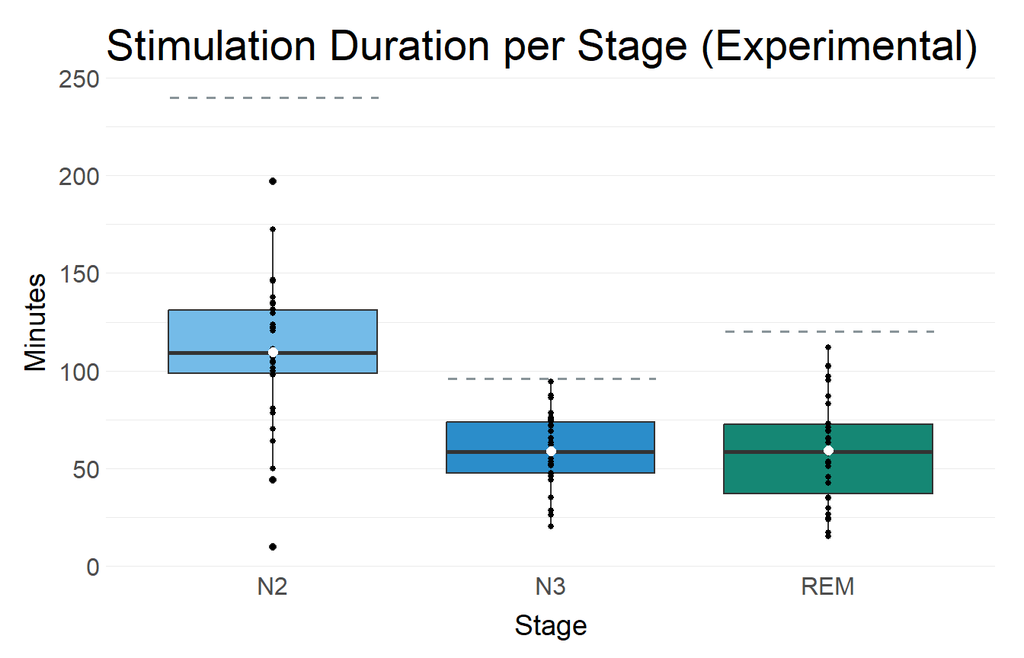

*Figure: Stimulation duration per sleep stage across subjects, in the experimental condition. Dotted lines represent the usual time spent per night in a given stage. White dots mark mean values.*

Mean duration N2: 109.4166667  
Mean duration N3: 58.9833333  
Mean duration REM: 59.15

## H1a: W<sub>exp</sub> > W<sub>con</sub>

### Parametric test assumptions

Normality of difference scores (exp - con):

```
## [1] "Assumption of normality valid, Shapiro-Wilk test not significant"
```

Outliers (con):

```
## [1] "None"
```

Outliers (exp):

```
## [1] "None"
```

### Statistical test

First, for stage W, we postulated that on average, the PSD40 value would be higher in the experimental than in the control condition (H1a). A directed paired t-test confirmed this hypothesis (*p* = 4.84e-11). The effect size was large, with a Cohen’s *d<sub>z</sub>* of 1.75 (CI = [1.19 ; 2.31]).

## H2a: N2<sub>exp</sub> > N2<sub>con</sub>

### Parametric test assumptions

Normality of difference scores (exp - con):

```
## [1] "Assumption of normality valid, Shapiro-Wilk test not significant"
```

Outliers (con):

```
## [1] "None"
```

Outliers (exp):

```
## [1] "None"
```

### Statistical test

Likewise, for stage N2, we postulated that on average, the PSD40 value would be higher in the experimental than in the control condition (H2a). A directed paired t-test confirmed this hypothesis (*p* = 1.29e-03). The effect size was medium, with a Cohen’s *d<sub>z</sub>* of 0.59 (CI = [0.21 ; 0.97]).

## H3a: N3<sub>exp</sub> > N3<sub>con</sub>

### Parametric test assumptions

Normality of difference scores (exp - con):

```
## [1] "Assumption of normality valid, Shapiro-Wilk test not significant"
```

Outliers (con):

```
## [1] "None"
```

Outliers (exp):

```
## [1] "None"
```

### Statistical test

For stage N3, we also expected that on average, the PSD40 value would be higher in the experimental than in the control condition (H3a). A directed paired t-test confirmed this hypothesis (*p* = 1.86e-03). The effect size was medium, with a Cohen’s *d<sub>z</sub>* of 0.56 (CI = [0.18 ; 0.94]).

## H4a: REM<sub>exp</sub> > REM<sub>con</sub>

### Parametric test assumptions

Normality of difference scores (exp - con):

```
## [1] "Assumption of normality violated, Shapiro-Wilk test significant"
```

Outliers (con):

```
## [1] "None"
```

Outliers (exp):

```
## [1] "None"
```

### Statistical test

Analogously, for stage REM, we anticipated that on average, the PSD40 value would be higher in the experimental than in the control condition (H4a). A directed Wilcoxon signed rank test confirmed this hypothesis (*p* = 1.28e-07). The effect size was very large, with a rank biserial correlation *r* of 0.94 (CI = [0.88 ; 1]).

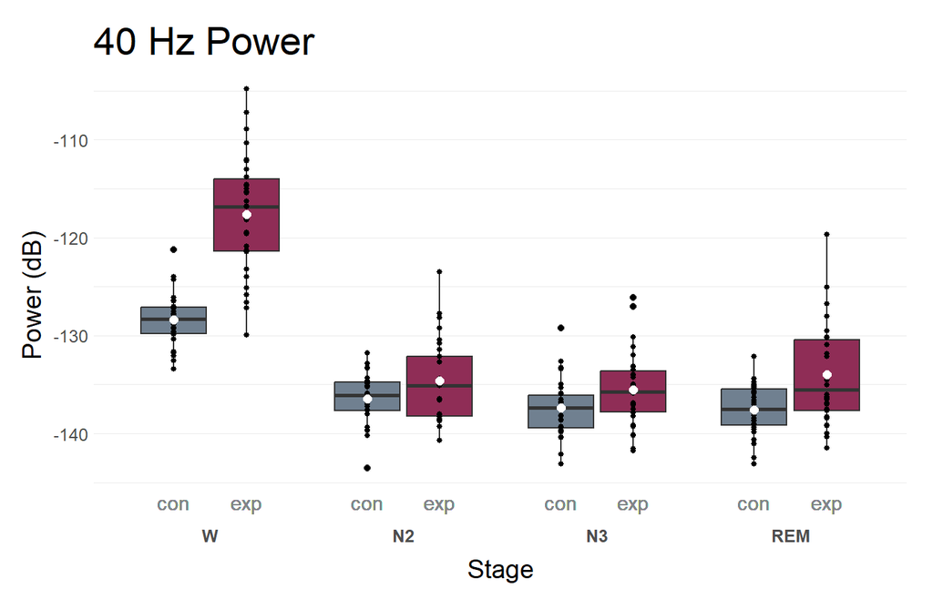

*Figure: Spectral power at 40 Hz across sleep stages. dB values closer to zero indicate higher spectral power. White dots mark mean values.*

## H5a: W<sub>exp</sub> =/= N2<sub>exp</sub> =/= N3<sub>exp</sub> =/= REM<sub>exp</sub>

### Parametric test assumptions

Normality of scores (W<sub>exp</sub>):

```
## [1] "Assumption of normality valid, Shapiro-Wilk test not significant"
```

Normality of scores (N2<sub>exp</sub>):

```
## [1] "Assumption of normality valid, Shapiro-Wilk test not significant"
```

Normality of scores (N3<sub>exp</sub>):

```
## [1] "Assumption of normality valid, Shapiro-Wilk test not significant"
```

Normality of scores (REM<sub>exp</sub>):

```
## [1] "Assumption of normality valid, Shapiro-Wilk test not significant"
```

Outliers (W<sub>exp</sub>):

```
## [1] "None"
```

Outliers (N2<sub>exp</sub>):

```
## [1] "None"
```

Outliers (N3<sub>exp</sub>):

```
## [1] "None"
```

Outliers (REM<sub>exp</sub>):

```
## [1] "None"
```

Sphericity:

```
## [1] "Assumption of sphericity violated, Mauchly test significant"
```

### Statistical test

Additionally, in the experimental condition, 40 Hz power was expected to differ between stages (H5a). A repeated measures ANOVA, Greenhouse-Geisser-corrected for sphericity deviations, confirmed this hypothesis (*p* = 2.56e-169). The effect size was large, with an eta squared of 0.9 (CI = [0.87 ; 1]). However, post-hoc tests reveal that only stage W differs from all other stages, with no significant differences between the sleep stages N2, N3, and REM (*p<sub>W-N2</sub>* = 1.37e-24, *p<sub>W-N3</sub>* = 2.71e-26, *p<sub>W-REM</sub>* = 2.01e-23, all other *p* = 1). We can conclude that 40 Hz power during stimulation is largest in W, and similarly large between sleep stages.

## Signal-to-Noise Ratio (SNR-PSD40)

Consistent with confirmatory analyses, all SNR values in the control condition are close to 1, and all SNR values in the experimental condition are higher than 1, with a markedly higher value in W<sub>exp</sub>.

```
##  stage condition     value
##     N2       con  1.047839
##     N3       con  1.025559
##    REM       con  1.045269
##      W       con  1.042527
##     N2       exp  2.010254
##     N3       exp  1.626257
##    REM       exp  2.411968
##      W       exp 17.068320
```

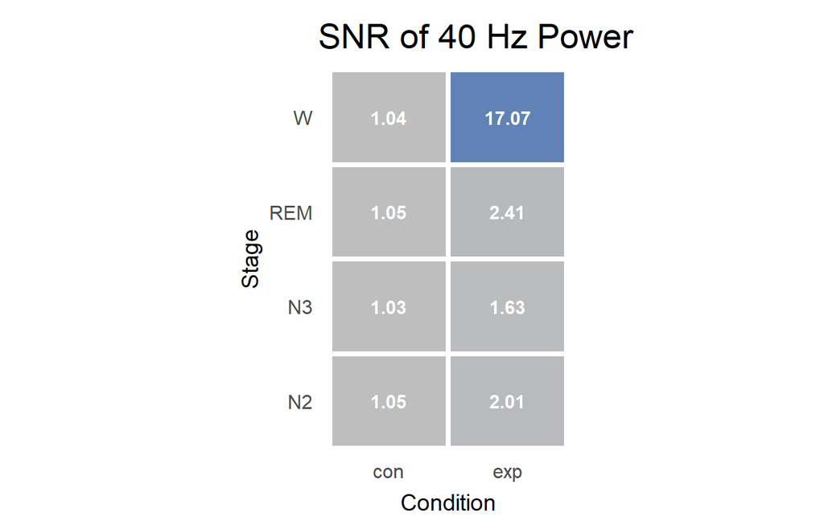

*Table: Median SNR values for PSD40. Medians were chosen over means due to outliers.*

# Secondary Analyses (Sleep Quality)

## Subjective Sleep Quality

### Parametric test assumptions

Normality of difference scores (exp - con):

```
## [1] "Assumption of normality valid, Shapiro-Wilk test not significant"
```

Outliers (con):

```
## [1] "None"
```

Outliers (exp):

```
## [1] "None"
```

### Statistical test

Regarding subjective sleep quality quantified as the GSQS sum score, we postulated that it would differ between the control and experimental condition. An undirected paired t-test confirmed this hypothesis (*p* = 0.01), indicating that sleep quality was perceived to be higher in the experimental (Mean<sub>exp</sub> = 2.73, SD<sub>exp</sub> = 2.56) than in the control (Mean<sub>con</sub> = 4.57, SD<sub>con</sub> = 3.28) night. The effect size was small, with a Cohen’s *d<sub>z</sub>* of 0.48 (CI = [0.11 ; 0.85]).

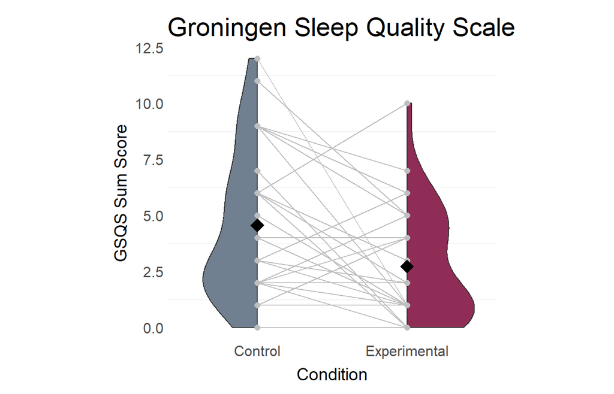

*Figure: Distribution of GSQS sum scores. Lower scores indicate better sleep quality. Dashed lines connect values for the control and experimental night, per participant. Black squares mark mean values.*

## Total Sleep Time

### Parametric test assumptions

Normality of difference scores (exp - con):

```
## [1] "Assumption of normality valid, Shapiro-Wilk test not significant"
```

Outliers (con):

```
## [1] "None"
```

Outliers (exp):

```
## [1] "Data points < -3 SD: Subject(s)"
## [1] "10"
```

### Statistical test

For TST as a marker of objective sleep quality, we also hypothesized that it would differ between the control and experimental condition. An undirected paired t-test rejected this hypothesis (*p* = 0.92), showing that on average, participants slept for a similarly long time in both the experimental (Mean<sub>exp</sub> = 420.13 min, SD<sub>exp</sub> = 30.06 min) and the control (Mean<sub>con</sub> = 420.75 min, SD<sub>con</sub> = 31.28 min) nights.

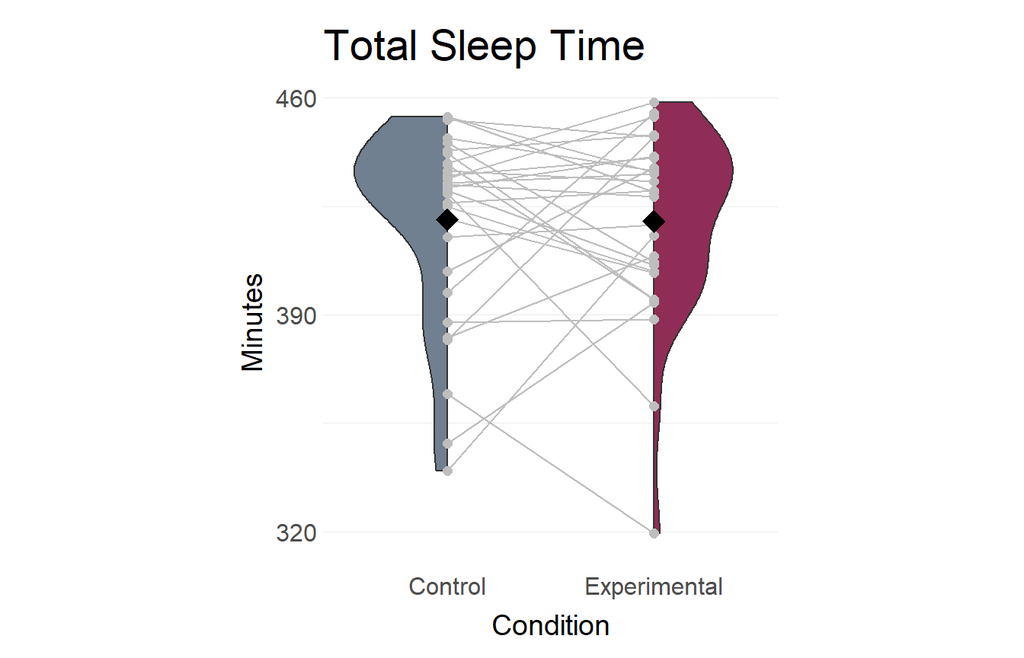

*Figure: Distribution of Total Sleep Times per condition. Dashed lines connect values for the control and experimental night, per participant. Black squares mark mean values.*

## Wake After Sleep Onset

### Parametric test assumptions

Normality of difference scores (exp - con):

```
## [1] "Assumption of normality valid, Shapiro-Wilk test not significant"
```

Outliers (con):

```
## [1] "Data points > 3 SD: Subject(s)"
## [1] "25"
```

Outliers (exp):

```
## [1] "None"
```

### Statistical test

For WASO as another marker of objective sleep quality, we also expected that it would differ between the control and experimental condition. An undirected paired t-test rejected this hypothesis (*p* = 0.16), implying that on average, participants spent a similar amount of time awake overnight in both the experimental (Mean<sub>exp</sub> = 40.85 min, SD<sub>exp</sub> = 21.34 min) and the control (Mean<sub>con</sub> = 48.75 min, SD<sub>con</sub> = 23.34 min) nights.

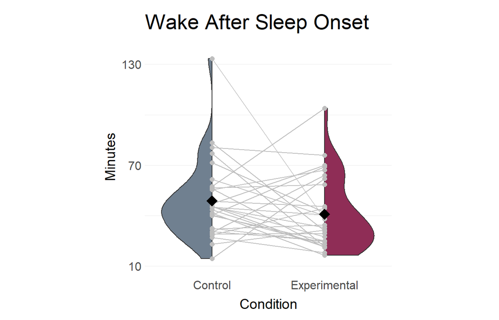

*Figure: Distribution of total Wake After Sleep Onset times per condition. Dashed lines connect values for the control and experimental night, per participant. Black squares mark mean values.*

## Time per Stage

Lastly, Time per Stage descriptively points to a sleep stage distribution common in healthy, young sleepers. Both nights are very similar, with lowest values for N1 (Mean<sub>con</sub> = 8.19 %, Mean<sub>exp</sub> = 8.01 %), highest values for N2 (Mean<sub>con</sub> = 53.38 %, Mean<sub>exp</sub> = 52.53 %), and both N3 (Mean<sub>con</sub> = 17.41 %, Mean<sub>exp</sub> = 16.82 %) and REM (Mean<sub>con</sub> = 21.02 %, Mean<sub>exp</sub> = 22.64 %) in-between.

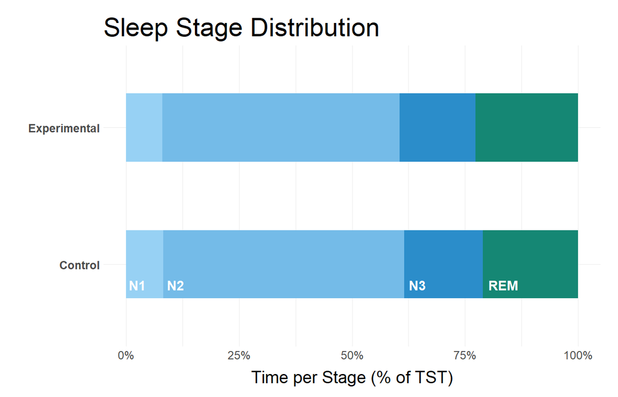

*Figure: Average time spent in each stage, as a percentage of the total time asleep, across participants.*

# Secondary Analyses (SSVEPamp)

## Descriptive

```
##     Median_uV_con Median_uV_exp IQR_uV_con IQR_uV_exp Mean_nr_segments_con
## W            0.11          0.96       0.11       0.95             142847.3
## N2           0.02          0.08       0.02       0.08             493731.4
## N3           0.02          0.07       0.03       0.06             166411.4
## REM          0.02          0.09       0.03       0.11             197698.5
##     Mean_nr_segments_exp
## W               47102.17
## N2             249354.27
## N3             142389.30
## REM            136729.37
```

## H1b: W<sub>exp</sub> > W<sub>con</sub>

### Parametric test assumptions

Normality of difference scores (exp - con):

```
## [1] "Assumption of normality violated, Shapiro-Wilk test significant"
```

Outliers (con):

```
## [1] "Data points > 3 SD: Subject(s)"
## [1] "23"
```

Outliers (exp):

```
## [1] "Data points > 3 SD: Subject(s)"
## [1] "08"
```

### Statistical test

For stage W, we postulated that on average, the SSVEPamp value would be higher in the experimental than in the control condition (H1b). A directed Wilcoxon signed rank test confirmed this hypothesis (*p* = 4.66e-09). The effect size was very large, with a rank biserial correlation *r* of 0.99 (CI = [0.97 ; 1]).

## H2b: N2<sub>exp</sub> > N2<sub>con</sub>

### Parametric test assumptions

Normality of difference scores (exp - con):

```
## [1] "Assumption of normality violated, Shapiro-Wilk test significant"
```

Outliers (con):

```
## [1] "Data points > 3 SD: Subject(s)"
## [1] "17"
```

Outliers (exp):

```
## [1] "Data points > 3 SD: Subject(s)"
## [1] "04"
```

### Statistical test

For stage N2, we also hypothesized that on average, the SSVEPamp value would be higher in the experimental than in the control condition (H2b). A directed Wilcoxon signed rank test confirmed this hypothesis (*p* = 1.38e-06). The effect size was very large, with a rank biserial correlation *r* of 0.88 (CI = [0.77 ; 1]).

## H3b: N3<sub>exp</sub> > N3<sub>con</sub>

### Parametric test assumptions

Normality of difference scores (exp - con):

```
## [1] "Assumption of normality valid, Shapiro-Wilk test not significant"
```

Outliers (con):

```
## [1] "None"
```

Outliers (exp):

```
## [1] "None"
```

### Statistical test

For stage N3, we equally expected that on average, the SSVEPamp value would be higher in the experimental than in the control condition (H3b). A directed paired t-test confirmed this hypothesis (*p* = 2.49e-04). The effect size was medium, with a Cohen’s *d<sub>z</sub>* of 0.7 (CI = [0.31 ; 1.09]).

## H4b: REM<sub>exp</sub> > REM<sub>con</sub>

### Parametric test assumptions

Normality of difference scores (exp - con):

```
## [1] "Assumption of normality violated, Shapiro-Wilk test significant"
```

Outliers (con):

```
## [1] "Data points > 3 SD: Subject(s)"
## [1] "04" "17"
```

Outliers (exp):

```
## [1] "Data points > 3 SD: Subject(s)"
## [1] "11"
```

### Statistical test

For stage REM as well, we anticipated that on average, the SSVEPamp value would be higher in the experimental than in the control condition (H4b). A directed Wilcoxon signed rank test confirmed this hypothesis (*p* = 1.18e-05). The effect size was very large, with a rank biserial correlation *r* of 0.82 (CI = [0.66 ; 1]).

## H5b: W<sub>exp</sub> =/= N2<sub>exp</sub> =/= N3<sub>exp</sub> =/= REM<sub>exp</sub>

### Parametric test assumptions

Normality of scores (W<sub>exp</sub>):

```
## [1] "Assumption of normality violated, Shapiro-Wilk test significant"
```

Normality of scores (N2<sub>exp</sub>):

```
## [1] "Assumption of normality violated, Shapiro-Wilk test significant"
```

Normality of scores (N3<sub>exp</sub>):

```
## [1] "Assumption of normality violated, Shapiro-Wilk test significant"
```

Normality of scores (REM<sub>exp</sub>):

```
## [1] "Assumption of normality violated, Shapiro-Wilk test significant"
```

Outliers (W<sub>exp</sub>):

```
## [1] "Data points > 3 SD: Subject(s)"
## [1] "08"
```

Outliers (N2<sub>exp</sub>):

```
## [1] "Data points > 3 SD: Subject(s)"
## [1] "04"
```

Outliers (N3<sub>exp</sub>):

```
## [1] "None"
```

Outliers (REM<sub>exp</sub>):

```
## [1] "Data points > 3 SD: Subject(s)"
## [1] "11"
```

Sphericity:

```
## [1] "Assumption of sphericity violated, Mauchly test significant"
```

### Statistical test

Additionally, in the experimental condition, SSVEP amplitude was expected to differ between stages (H5b). A Friedman ANOVA confirmed this hypothesis (*p* = 4.04e-13). A Kendall’s *w* of 0.68 (CI = [0.62 ; 1]) indicates “substantial agreement”. However, post-hoc tests reveal that only stage W differs from all other stages, with no significant difference between the sleep stages N2, N3, and REM (*p<sub>W-N2</sub>* = 1.5e-12, *p<sub>W-N3</sub>* = 5.15e-14, *p<sub>W-REM</sub>* = 1.54e-10, all other *p* = 1). We can conclude that SSVEP amplitude during stimulation is largest in W, and similarly large between sleep stages.

## Signal-to-Noise Ratio (SNR-SSVEPamp)

```
##  stage condition     value
##     N2       con 0.8527998
##     N3       con 0.5910849
##    REM       con 0.7655222
##      W       con 1.1881686
##     N2       exp 2.6317243
##     N3       exp 1.6803954
##    REM       exp 2.8148168
##      W       exp 6.2597261
```

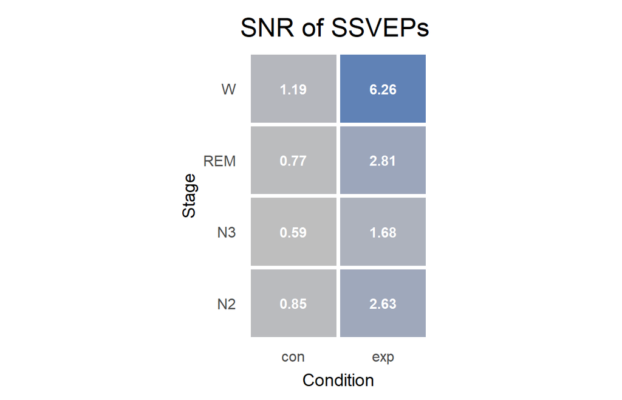

*Table: Median SNR values for SSVEPamp. Medians were chosen over means due to outliers.*

## Time Series Plots

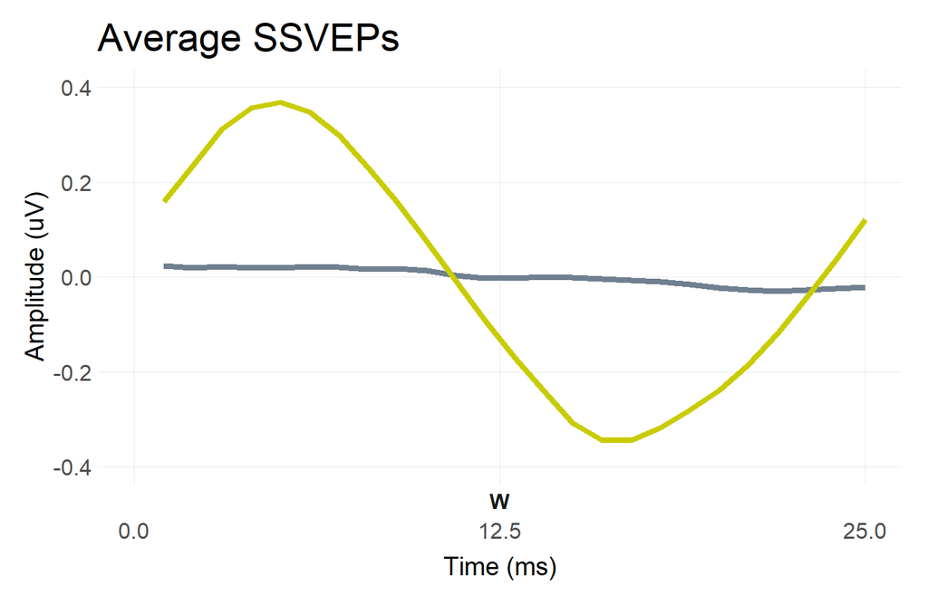

*Figure: SSVEPs averaged across all subjects by condition, in wakefulness.*

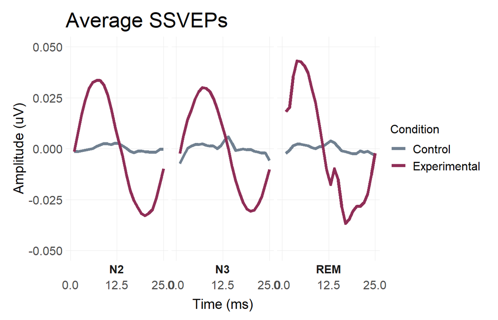

*Figure: SSVEPs averaged across all subjects by condition, in the three sleep stages.*

# Extra Analyses

## Correlations: Nr. of Epochs x PSD40

*Post-hoc*, Pearson correlations were computed between the number of epochs stimulated and PSD40, in the experimental condition, stratified by sleep stage. Overall, correlations are small (positive for N2 and N3, negative for REM).

*r<sub>N2</sub>* = 0.15  
*r<sub>N3</sub>* = 0.17  
*r<sub>REM</sub>* = -0.2

## REM Latency

### Parametric test assumptions

Normality of difference scores (exp - con):

```
## [1] "Assumption of normality valid, Shapiro-Wilk test not significant"
```

Outliers (con):

```
## [1] "None"
```

Outliers (exp):

```
## [1] "None"
```

### Statistical test

REM latency was inspected post-hoc. An undirected paired t-test was significant (*p* = 0.01), showing that on average, participants had a shorter REM sleep latency in the experimental condition (Mean<sub>exp</sub> = 93.52 min, SD<sub>exp</sub> = 42.65 min) than in the control condition (Mean<sub>con</sub> = 119.78 min, SD<sub>con</sub> = 50.76 min).

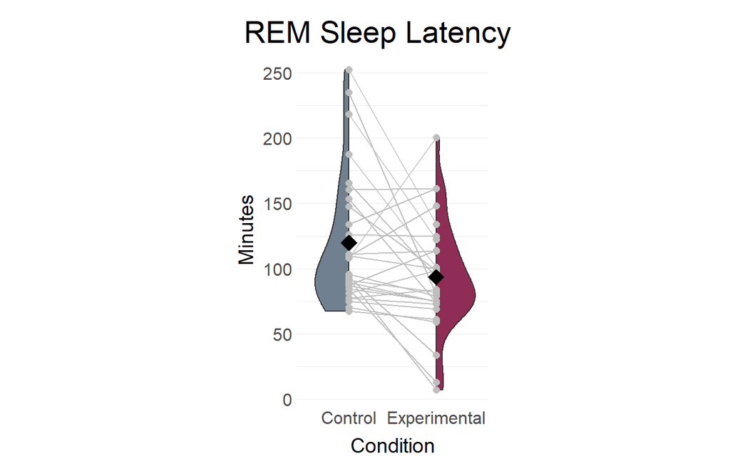

*Figure: Distribution of REM sleep latencies per condition. Dashed lines connect values for the control and experimental night, per participant. Black squares mark mean values.*

## REMs

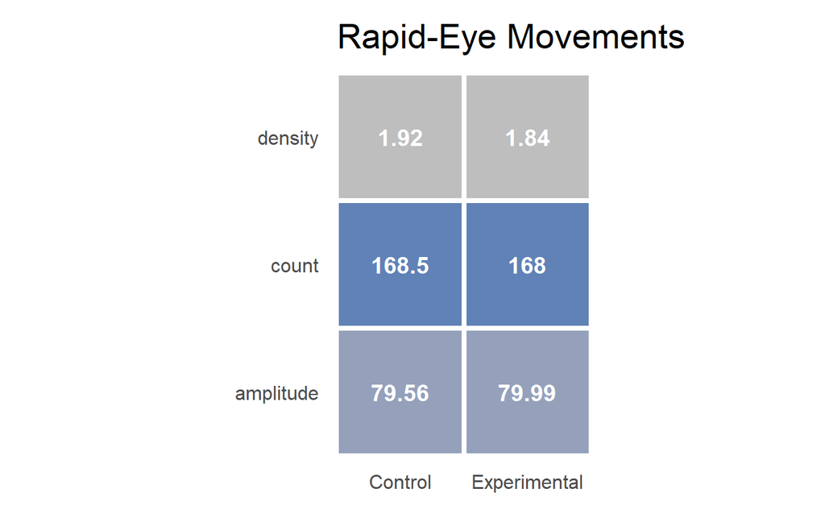

## Spindles

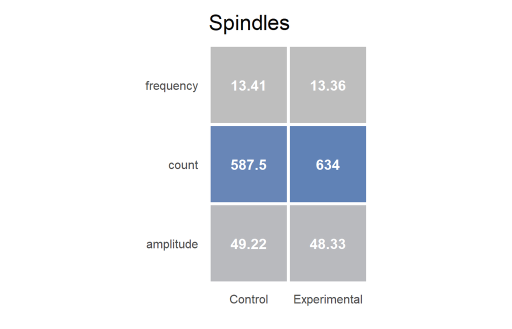

### Post-hoc test: spindle count

A post-hoc undirected paired t-test did not reveal significant differences in the amount of spindles in N2 and N3 between conditions (*p* = 0.7).

## SOs

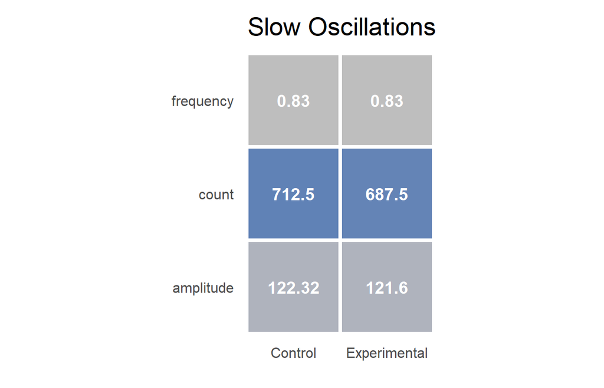

### Post-hoc test: slow oscillation count

A post-hoc undirected paired t-test did not reveal significant differences in the amount of slow oscillations in N2 and N3 between conditions (*p* = 0.75).